# Name: Aaron Zheng

# MGT 4803 Business Analytics II

# Final Project

## Setting Up All Libraries and Setting Working Directory

```r
library(dplyr)
```

```r
library(ggplot2)
library(caret)
library(ROCR)
library(car)
library(corrplot)
library(MASS)
library(leaps)
setwd("C:/Users/AZhen/OneDrive/GA Tech Fall 2022/MGT 4803 Business Analytics II")
```

## Importing Dataset and Formatting/Cleaning Data

```r
tweets <- read.csv("MAX Tweets.csv")
str(tweets)
```

```
## 'data.frame':    1209 obs. of  26 variables:
##  $ Date                : chr  "1/5/2017" "1/6/2017" "1/7/2017" "1/8/2017" ...
##  $ Combo               : num  1.40e+14 2.47e+09 2.47e+08 3.33e+09 2.60e+09 ...
##  $ Combo.1             : num  1.40e+14 2.47e+09 2.47e+08 3.33e+09 2.60e+09 ...
##  $ TSLA.Up             : int  1 1 1 1 0 1 1 0 0 0 ...
##  $ TSLA.Change         : num  0.00146 0.00916 0.01009 0.01009 -0.00918 ...
##  $ nlikes              : chr  "14,041" "247" "247" "333" ...
##  $ nreplies            : chr  "469" "27" "16" "23" ...
##  $ nretweets           : chr  "2,873" "80" "25" "28" ...
##  $ normalized.nlikes   : num  -0.11 -0.338 -0.338 -0.336 -0.337 ...
##  $ normalized.nreplies : num  -0.0602 -0.2885 -0.2942 -0.2906 -0.2839 ...
##  $ normalized.nretweets: num  0.0649 -0.2145 -0.22 -0.2197 -0.2195 ...
##  $ Day                 : int  4 5 6 7 2 3 4 6 7 1 ...
##  $ Hour                : int  21 23 3 13 23 3 21 19 22 10 ...
##  $ X5.Day.Momentum     : num  0.0319 0.0668 0.0823 0.0823 0.0594 ...
##  $ X10.Day.Momentum    : num  0.086 0.1026 0.1095 0.1095 0.0775 ...
##  $ NASDAQ.Change       : num  0.002475 0.003997 0.000767 0.000767 0.00276 ...
##  $ DJIA.Change         : num  -0.00127 0.00286 -0.00221 -0.00221 -0.00105 ...
##  $ S.P.500.Change      : num  -0.00224 -0.00224 -0.00224 -0.00224 -0.00224 ...
##  $ XLK.Change          : num  -0.0648 -0.0604 -0.068 -0.068 -0.0673 ...
##  $ Monday              : int  0 0 0 0 0 0 0 0 0 1 ...
##  $ Tuesday             : int  0 0 0 0 1 0 0 0 0 0 ...
##  $ Wednesday           : int  0 0 0 0 0 1 0 0 0 0 ...
##  $ Thursday            : int  1 0 0 0 0 0 1 0 0 0 ...
##  $ Friday              : int  0 1 0 0 0 0 0 0 0 0 ...
##  $ AVG.Sentiment       : num  -0.433 0 0.5 -0.25 0.175 ...
##  $ SUM.Sentiment       : num  -1.3 0 0.5 -0.25 0.35 0 0.5 0 -0.4 1 ...
```

```r
tweets$nlikes <- as.integer(gsub(",","",tweets$nlikes))
tweets$nreplies <- as.integer(gsub(",","",tweets$nreplies))
tweets$nretweets <- as.integer(gsub(",","",tweets$nretweets))

#Removing unnecessary columns
tweets <- subset(tweets,select = -c(2,3))

#Using Date column as index and removing Date column
rownames(tweets) <- tweets$Date
tweets <- subset(tweets,select = -c(1))
```

## Checking correlation matrix before running regressions

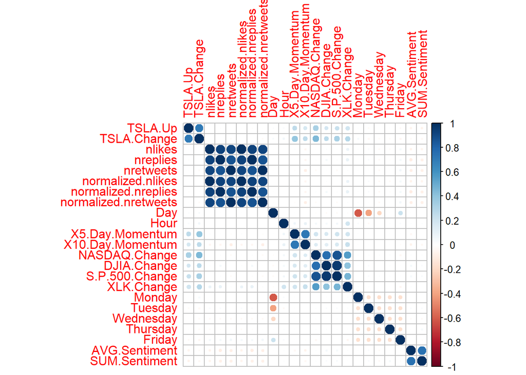

```r
corrplot(cor(tweets))
```

# LINEAR REGRESSIONS

```r
#linear regression with all variables
linear_regression <- lm(TSLA.Change ~ nlikes +nreplies + nretweets + Hour + X5.Day.Momentum + X10.Day.Momentum
                        + NASDAQ.Change + DJIA.Change + S.P.500.Change + XLK.Change + Monday + Tuesday
                        + Wednesday + Thursday + Friday + AVG.Sentiment + SUM.Sentiment, data = tweets)

summary(linear_regression)
```

```
##
## Call:
## lm(formula = TSLA.Change ~ nlikes + nreplies + nretweets + Hour +
##     X5.Day.Momentum + X10.Day.Momentum + NASDAQ.Change + DJIA.Change +
##     S.P.500.Change + XLK.Change + Monday + Tuesday + Wednesday +
##     Thursday + Friday + AVG.Sentiment + SUM.Sentiment, data = tweets)
##
## Residuals:
##       Min        1Q    Median        3Q       Max
## -0.119833 -0.015160 -0.001508  0.012972  0.126561
##
## Coefficients:
##                    Estimate Std. Error t value Pr(>|t|)
## (Intercept)       3.308e-03  3.529e-03   0.937 0.348845
## nlikes            9.828e-09  3.565e-08   0.276 0.782870
## nreplies         -4.739e-07  1.131e-06  -0.419 0.675197
## nretweets        -3.440e-08  1.658e-07  -0.207 0.835682
## Hour              9.851e-05  1.188e-04   0.829 0.407013
## X5.Day.Momentum   1.149e-01  1.119e-02  10.273  < 2e-16 ***
## X10.Day.Momentum -9.801e-03  7.989e-03  -1.227 0.220127
## NASDAQ.Change     1.959e+00  1.756e-01  11.157  < 2e-16 ***
## DJIA.Change       4.178e-01  2.886e-01   1.448 0.147943
## S.P.500.Change   -1.469e+00  4.084e-01  -3.597 0.000334 ***
## XLK.Change        1.122e-02  5.050e-02   0.222 0.824248
## Monday           -8.158e-04  2.496e-03  -0.327 0.743819
## Tuesday          -6.551e-03  2.494e-03  -2.626 0.008748 **
## Wednesday        -5.796e-03  2.452e-03  -2.364 0.018252 *
## Thursday         -6.079e-03  2.491e-03  -2.440 0.014818 *
## Friday           -5.626e-03  2.489e-03  -2.261 0.023968 *
## AVG.Sentiment     2.076e-03  2.956e-03   0.702 0.482608
## SUM.Sentiment    -2.183e-03  1.335e-03  -1.636 0.102181
## ---
## Signif. codes:  0 '***' 0.001 '**' 0.01 '*' 0.05 '.' 0.1 ' ' 1
##
## Residual standard error: 0.02653 on 1191 degrees of freedom
## Multiple R-squared:  0.3209, Adjusted R-squared:  0.3112
## F-statistic: 33.11 on 17 and 1191 DF,  p-value: < 2.2e-16
```

```r
vif(linear_regression)
```

```
##           nlikes         nreplies        nretweets             Hour
##        11.713793         7.179165         6.642736         1.054977
##  X5.Day.Momentum X10.Day.Momentum    NASDAQ.Change      DJIA.Change
##         2.076849         2.103327         5.979429        14.190439
##   S.P.500.Change       XLK.Change           Monday          Tuesday
##        25.187635         1.611703         1.305178         1.310204
##        Wednesday         Thursday           Friday    AVG.Sentiment
##         1.320584         1.312836         1.322914         2.288276
##    SUM.Sentiment
##         2.258965
```

## Testing hypothesis: does ignoring unpopular tweets make the model more accurate?

## Base R-Squared: 0.3209

## Goal of below for loop: Find cutoff range of tweet popularity where variables are still significant. Maximize Adjusted R-Squared.

```r
maxrsquared = 0

for (x in 0:1500) {
  populartweets <- tweets[tweets$nlikes > x*100,]
  popularlinear_regression <- lm(TSLA.Change ~ normalized.nlikes + normalized.nreplies + normalized.nretweets
                                 + Day + Hour + X5.Day.Momentum + X10.Day.Momentum + NASDAQ.Change + DJIA.Change
                                 + S.P.500.Change + XLK.Change + Monday + Tuesday + Wednesday + Thursday + Friday
                                 + AVG.Sentiment + SUM.Sentiment, data = populartweets)

  #ends for loop if no variables are significant anymore
  #sigcount = sum(summary(popularlinear_regression)$coefficients[,4] <= 0.001)
  if((sum(summary(popularlinear_regression)$coefficients[,4] <= 0.001)) < 1){
    break}

  maxr = summary(popularlinear_regression)$adj.r.squared


  #replaces old max with new max
   if(maxr > maxrsquared){
    maxrsquared = maxr}

}
nlikecap <- (x-1)*100
```

## The maximum nlike cutoff before no variables were significant at the p-value <= 0.001 level was 50,600 likes.

## R-squared of this model including all variables is 0.4778

```r
populartweets <- tweets[tweets$nlikes > 50600,]
popularlinear_regression <- lm(TSLA.Change ~ normalized.nlikes + normalized.nreplies + normalized.nretweets
                               + Day + Hour + X5.Day.Momentum + X10.Day.Momentum + NASDAQ.Change + DJIA.Change
                               + S.P.500.Change + XLK.Change + Monday + Tuesday + Wednesday + Thursday + Friday
                               + AVG.Sentiment + SUM.Sentiment, data = populartweets)

summary(popularlinear_regression)
```

```
##
## Call:
## lm(formula = TSLA.Change ~ normalized.nlikes + normalized.nreplies +
##     normalized.nretweets + Day + Hour + X5.Day.Momentum + X10.Day.Momentum +
##     NASDAQ.Change + DJIA.Change + S.P.500.Change + XLK.Change +
##     Monday + Tuesday + Wednesday + Thursday + Friday + AVG.Sentiment +
##     SUM.Sentiment, data = populartweets)
##
## Residuals:
##       Min        1Q    Median        3Q       Max
## -0.087769 -0.014015 -0.001727  0.014349  0.078423
##
## Coefficients:
##                        Estimate Std. Error t value Pr(>|t|)
## (Intercept)           1.249e-01  8.304e-02   1.503 0.135869
## normalized.nlikes    -9.677e-06  2.926e-03  -0.003 0.997368
## normalized.nreplies  -2.246e-03  2.531e-03  -0.888 0.376908
## normalized.nretweets  3.092e-04  2.141e-03   0.144 0.885484
## Day                  -1.563e-02  1.207e-02  -1.295 0.198304
## Hour                 -1.117e-04  4.117e-04  -0.271 0.786641
## X5.Day.Momentum       8.804e-02  3.195e-02   2.755 0.006969 **
## X10.Day.Momentum      7.110e-03  2.368e-02   0.300 0.764633
## NASDAQ.Change         1.936e+00  5.243e-01   3.693 0.000361 ***
## DJIA.Change           1.641e+00  1.031e+00   1.591 0.114772
## S.P.500.Change       -2.538e+00  1.430e+00  -1.775 0.079008 .
## XLK.Change            3.318e-01  1.769e-01   1.876 0.063533 .
## Monday               -8.628e-02  6.813e-02  -1.266 0.208324
## Tuesday              -8.927e-02  5.613e-02  -1.590 0.114917
## Wednesday            -5.495e-02  4.419e-02  -1.244 0.216544
## Thursday             -4.214e-02  3.293e-02  -1.279 0.203718
## Friday               -2.589e-02  2.104e-02  -1.231 0.221331
## AVG.Sentiment        -5.178e-03  1.172e-02  -0.442 0.659568
## SUM.Sentiment        -2.530e-03  5.581e-03  -0.453 0.651311
## ---
## Signif. codes:  0 '***' 0.001 '**' 0.01 '*' 0.05 '.' 0.1 ' ' 1
##
## Residual standard error: 0.02665 on 100 degrees of freedom
## Multiple R-squared:  0.4778, Adjusted R-squared:  0.3839
## F-statistic: 5.084 on 18 and 100 DF,  p-value: 4.852e-08
```

## BELOW IS WHAT I ATTEMPTED BEFORE I REALIZED I WAS MANUALLY DOING A STEPWISE REGRESSION

## Discard dependent variables, integer nlikes,nreplies,nretweets, AND normalized.replies, normalized.nretweets

## normalized.nlikes is enough

```r
columnnames <- colnames(tweets)
columnnames <- columnnames[-c(1,2,3,4,5,7,8)]
```

## Create grid of all combinations of the remaining 16 variables, keep all combos with more than 2 variables.

## AKA Variable Data Frame

```r
vardf <- as.data.frame(expand.grid(0:1, 0:1, 0:1, 0:1, 0:1, 0:1, 0:1, 0:1, 0:1, 0:1, 0:1, 0:1, 0:1, 0:1, 0:1, 0:1))
vardf$rowsums <- rowSums(vardf)
vardf <- vardf[vardf$rowsums > 2,]
```

## Loop through all possible combos to verify the maximum adjusted R-Squared.

## If you refresh the environment while this is running, you can see where iterator “i” is at out of 65399 possible combinations.

```r
loopmaxr= 0
loopmaxi = 0

#Outer loop: loop through variable combo grid rows
for(i in 1:nrow(vardf)) {

  reg_formula = ""
  vars = ""
  x = 0

  #for each row, create formula based on selected variables
  for(x in 2:length(vardf[i,])-1){
    #print(x)
    if (isTRUE(vardf[i,x] == 1)){
      reg_formula = paste(reg_formula, columnnames[x], sep = " + ")
    }
  }
  vars = substring(reg_formula,3)
  fullequ = paste("TSLA.Change ~ ", vars, sep = "")
  loop_regression <- lm(as.formula(fullequ), data = tweets)

  #gets max R-squared and Row
  if (summary(loop_regression)$adj.r.squared > loopmaxr){
    loopmaxr = summary(loop_regression)$adj.r.squared
    loopmaxi = i
    }
}
```

## Combination of variables for maximum adjusted R-squared

- X5.Day.Momentum
- X10.Day.Momentum
- NASDAQ.Change
- DJIA.Change
- S.P.500.Change
- Tuesday
- Wednesday
- Thursday
- Friday
- SUM.Sentiment

```r
vardf[loopmaxi,]
```

```
##       Var1 Var2 Var3 Var4 Var5 Var6 Var7 Var8 Var9 Var10 Var11 Var12 Var13
## 48377    0    0    0    1    1    1    1    1    0     0     1     1     1
##       Var14 Var15 Var16 rowsums
## 48377     1     0     1      10
```

```r
for (i in 1:length(columnnames)){
  print(paste(i, columnnames[i]))
}
```

```
## [1] "1 normalized.nlikes"
## [1] "2 Day"
## [1] "3 Hour"
## [1] "4 X5.Day.Momentum"
## [1] "5 X10.Day.Momentum"
## [1] "6 NASDAQ.Change"
## [1] "7 DJIA.Change"
## [1] "8 S.P.500.Change"
## [1] "9 XLK.Change"
## [1] "10 Monday"
## [1] "11 Tuesday"
## [1] "12 Wednesday"
## [1] "13 Thursday"
## [1] "14 Friday"
## [1] "15 AVG.Sentiment"
## [1] "16 SUM.Sentiment"
```

# Stepwise version 1

## Only difference in above result is BELOW does not include 10-Day momentum variable

```r
stepwise1 <- stepAIC(linear_regression, direction = "both",
                      trace = FALSE)
summary(stepwise1)
```

```
##
## Call:
## lm(formula = TSLA.Change ~ X5.Day.Momentum + NASDAQ.Change +
##     DJIA.Change + S.P.500.Change + Tuesday + Wednesday + Thursday +
##     Friday + SUM.Sentiment, data = tweets)
##
## Residuals:
##       Min        1Q    Median        3Q       Max
## -0.119422 -0.015198 -0.001432  0.013325  0.129835
##
## Coefficients:
##                   Estimate Std. Error t value Pr(>|t|)
## (Intercept)      0.0041246  0.0012592   3.276 0.001084 **
## X5.Day.Momentum  0.1055615  0.0079616  13.259  < 2e-16 ***
## NASDAQ.Change    1.9719259  0.1650999  11.944  < 2e-16 ***
## DJIA.Change      0.4076760  0.2848482   1.431 0.152632
## S.P.500.Change  -1.4600452  0.4031807  -3.621 0.000305 ***
## Tuesday         -0.0063368  0.0023368  -2.712 0.006788 **
## Wednesday       -0.0054914  0.0022939  -2.394 0.016822 *
## Thursday        -0.0058518  0.0023310  -2.510 0.012188 *
## Friday          -0.0053144  0.0023243  -2.286 0.022403 *
## SUM.Sentiment   -0.0013600  0.0008889  -1.530 0.126281
## ---
## Signif. codes:  0 '***' 0.001 '**' 0.01 '*' 0.05 '.' 0.1 ' ' 1
##
## Residual standard error: 0.02648 on 1199 degrees of freedom
## Multiple R-squared:  0.319,  Adjusted R-squared:  0.3139
## F-statistic: 62.41 on 9 and 1199 DF,  p-value: < 2.2e-16
```

# Stepwise version 2

```r
stepwisetweets <- subset(tweets, select = -c(1))
stepwise2 <- regsubsets(TSLA.Change~., data = stepwisetweets, nvmax = 21,
                     method = "seqrep")
summary(stepwise2)
```

```
## Subset selection object
## Call: regsubsets.formula(TSLA.Change ~ ., data = stepwisetweets, nvmax = 21,
##     method = "seqrep")
## 21 Variables  (and intercept)
##                      Forced in Forced out
## nlikes                   FALSE      FALSE
## nreplies                 FALSE      FALSE
## nretweets                FALSE      FALSE
## normalized.nlikes        FALSE      FALSE
## normalized.nreplies      FALSE      FALSE
## normalized.nretweets     FALSE      FALSE
## Day                      FALSE      FALSE
## Hour                     FALSE      FALSE
## X5.Day.Momentum          FALSE      FALSE
## X10.Day.Momentum         FALSE      FALSE
```

[output cut: 101 more lines]

## Discard all non-significant variables for simplest regression model

## R-Squared: 0.3082

## Only MINIMAL loss in R-squared with 3 variable model

```r
simplest_regression <- lm(TSLA.Change~X5.Day.Momentum
                        + NASDAQ.Change + S.P.500.Change, data = tweets)


summary(simplest_regression)
```

```
##
## Call:
## lm(formula = TSLA.Change ~ X5.Day.Momentum + NASDAQ.Change +
##     S.P.500.Change, data = tweets)
##
## Residuals:
##      Min       1Q   Median       3Q      Max
## -0.11985 -0.01460 -0.00235  0.01314  0.13087
##
## Coefficients:
##                   Estimate Std. Error t value Pr(>|t|)
## (Intercept)      0.0002823  0.0007851   0.360    0.719
## X5.Day.Momentum  0.1046738  0.0079650  13.142  < 2e-16 ***
## NASDAQ.Change    1.8794444  0.1448132  12.978  < 2e-16 ***
## S.P.500.Change  -0.9709496  0.1643679  -5.907 4.52e-09 ***
## ---
## Signif. codes:  0 '***' 0.001 '**' 0.01 '*' 0.05 '.' 0.1 ' ' 1
##
## Residual standard error: 0.02663 on 1205 degrees of freedom
## Multiple R-squared:  0.3082, Adjusted R-squared:  0.3065
## F-statistic: 178.9 on 3 and 1205 DF,  p-value: < 2.2e-16
```

```r
print("Difference between Max and Simple models:")
```

```
## [1] "Difference between Max and Simple models:"
```

```r
print(loopmaxr - summary(simplest_regression)$adj.r.squared)
```

```
## [1] 0.007599333
```

## Take #2 with Simplest Regression Model

## Testing hypothesis: does ignoring unpopular tweets make the model more accurate?

## Goal of below for loop: Find cutoff range of tweet popularity where variables are still significant. Maximize Adjusted R-Squared.

```r
maxrsquared2 = 0

for (y in 1:1500) {
  #print(y)
  simppoptweets <- tweets[tweets$nlikes > y*100,]
  simplepopular <- lm(TSLA.Change ~ X5.Day.Momentum
                  + NASDAQ.Change + S.P.500.Change, data = simppoptweets)

  #Sys.sleep(0.2)

  #ends for loop if no variables are significant anymore
  #sigcount2 = sum(summary(simplepopular)$coefficients[,4] <= 0.001)
  if((sum(summary(simplepopular)$coefficients[,4] <= 0.001)) < 1){
    break}

  maxr2 = summary(simplepopular)$adj.r.squared


  #replaces old max with new max
  if(maxr2 > maxrsquared2){
    maxrsquared2 = maxr2}
}
nlikecap2 = (y-1) *100
```

#The maximum nlike cutoff before no variables were significant at the p-value <= 0.001 level was 54,600 likes. #R-Squared: 0.3756

```r
simppoptweets <- tweets[tweets$nlikes > 54600,]
simplepopular <- lm(TSLA.Change ~ X5.Day.Momentum
                    + NASDAQ.Change + S.P.500.Change, data = simppoptweets)

summary(simplepopular)
```

```
##
## Call:
## lm(formula = TSLA.Change ~ X5.Day.Momentum + NASDAQ.Change +
##     S.P.500.Change, data = simppoptweets)
##
## Residuals:
##       Min        1Q    Median        3Q       Max
## -0.091128 -0.015563 -0.003079  0.013590  0.095206
##
## Coefficients:
##                  Estimate Std. Error t value Pr(>|t|)
## (Intercept)      0.001465   0.002595   0.565 0.573581
## X5.Day.Momentum  0.084944   0.026602   3.193 0.001853 **
## NASDAQ.Change    1.376345   0.402902   3.416 0.000902 ***
## S.P.500.Change  -0.208722   0.464024  -0.450 0.653768
## ---
## Signif. codes:  0 '***' 0.001 '**' 0.01 '*' 0.05 '.' 0.1 ' ' 1
##
## Residual standard error: 0.0265 on 106 degrees of freedom
## Multiple R-squared:  0.3756, Adjusted R-squared:  0.358
## F-statistic: 21.26 on 3 and 106 DF,  p-value: 7.41e-11
```

# LOGISTIC REGRESSIONS

#Splitting data into training and validation sets 70/30 split

```r
set.seed(123)
tweets2<- tweets[sample(1:nrow(tweets)), ]
training <- tweets2[1:846,]
validation <- tweets2[847:1209,]


log_regression <- glm(TSLA.Up ~ nlikes +nreplies + nretweets + Hour + X5.Day.Momentum + X10.Day.Momentum
                        + NASDAQ.Change + DJIA.Change + S.P.500.Change + XLK.Change + Monday + Tuesday
                        + Wednesday + Thursday + Friday + AVG.Sentiment + SUM.Sentiment, data = training, family = "binomial")

summary(log_regression)
```

```
##
## Call:
## glm(formula = TSLA.Up ~ nlikes + nreplies + nretweets + Hour +
##     X5.Day.Momentum + X10.Day.Momentum + NASDAQ.Change + DJIA.Change +
##     S.P.500.Change + XLK.Change + Monday + Tuesday + Wednesday +
##     Thursday + Friday + AVG.Sentiment + SUM.Sentiment, family = "binomial",
##     data = training)
##
## Deviance Residuals:
##     Min       1Q   Median       3Q      Max
## -2.4191  -1.0192   0.2156   1.0007   2.1155
##
## Coefficients:
##                    Estimate Std. Error z value Pr(>|z|)
## (Intercept)      -3.104e-01  3.771e-01  -0.823  0.41037
## nlikes            1.714e-06  4.692e-06   0.365  0.71483
## nreplies         -1.938e-04  1.462e-04  -1.325  0.18502
## nretweets         6.078e-06  2.139e-05   0.284  0.77630
## Hour              1.341e-02  1.202e-02   1.115  0.26470
## X5.Day.Momentum   6.880e+00  1.310e+00   5.253 1.50e-07 ***
## X10.Day.Momentum -5.831e-02  8.323e-01  -0.070  0.94415
## NASDAQ.Change     1.652e+02  2.221e+01   7.442 9.95e-14 ***
## DJIA.Change       9.146e+01  3.251e+01   2.813  0.00491 **
## S.P.500.Change   -1.922e+02  4.802e+01  -4.003 6.25e-05 ***
## XLK.Change       -2.733e+00  5.484e+00  -0.498  0.61818
## Monday           -3.728e-02  2.608e-01  -0.143  0.88635
## Tuesday          -3.081e-02  2.573e-01  -0.120  0.90467
## Wednesday        -8.343e-02  2.489e-01  -0.335  0.73748
## Thursday         -2.157e-01  2.508e-01  -0.860  0.38980
## Friday           -2.316e-01  2.471e-01  -0.937  0.34859
## AVG.Sentiment     2.552e-02  3.101e-01   0.082  0.93441
## SUM.Sentiment    -1.406e-01  1.459e-01  -0.963  0.33543
## ---
## Signif. codes:  0 '***' 0.001 '**' 0.01 '*' 0.05 '.' 0.1 ' ' 1
##
## (Dispersion parameter for binomial family taken to be 1)
##
##     Null deviance: 1172.63  on 845  degrees of freedom
## Residual deviance:  976.88  on 828  degrees of freedom
## AIC: 1012.9
##
## Number of Fisher Scoring iterations: 4
```

## loops through 0.01 to 0.97 to find cutoff with lowest misclassification rate

## Base misclass rate at 0.52 cutoff: 0.3223

```r
min_misclassrate = 1
for (i in seq(0.01,0.97,by = 0.01)){
  validation2 <- data.frame(validation)
  validation2$Pred <- predict(log_regression, newdata = validation, type = "response")
  validation2 <- mutate(validation2, Prediction = ifelse(Pred > i, 1,0))
  conf <- confusionMatrix(as.factor(validation2$TSLA.Up), as.factor(validation2$Prediction))
  (conf$table[1,2] + conf$table[2,1])/1209
  if((conf$table[1,2] + conf$table[2,1])/1209 < min_misclassrate){
    min_misclassrate <- (conf$table[1,2] + conf$table[2,1])/1209
    print(i)
  }
}
```

```
## [1] 0.01
## [1] 0.03
## [1] 0.06
## [1] 0.07
## [1] 0.08
## [1] 0.09
## [1] 0.1
## [1] 0.11
## [1] 0.12
## [1] 0.13
## [1] 0.14
## [1] 0.18
## [1] 0.19
## [1] 0.2
## [1] 0.21
## [1] 0.22
## [1] 0.23
## [1] 0.28
## [1] 0.29
## [1] 0.35
## [1] 0.36
## [1] 0.37
## [1] 0.42
## [1] 0.52
```

## Comparing with logit with all variables vs simple logit model

```r
set.seed(123)
validation2 <- data.frame(validation)
  validation2$Pred <- predict(log_regression, newdata = validation, type = "response")
  validation2 <- mutate(validation2, Prediction = ifelse(Pred > 0.52, 1,0))
  confusionMatrix(as.factor(validation2$TSLA.Up), as.factor(validation2$Prediction))
```

```
## Confusion Matrix and Statistics
##
##           Reference
## Prediction   0   1
##          0 112  48
##          1  69 134
##
##                Accuracy : 0.6777
##                  95% CI : (0.6269, 0.7255)
##     No Information Rate : 0.5014
##     P-Value [Acc > NIR] : 8.049e-12
##
##                   Kappa : 0.3552
##
##  Mcnemar's Test P-Value : 0.06446
##
##             Sensitivity : 0.6188
##             Specificity : 0.7363
##          Pos Pred Value : 0.7000
##          Neg Pred Value : 0.6601
##              Prevalence : 0.4986
##          Detection Rate : 0.3085
##    Detection Prevalence : 0.4408
##       Balanced Accuracy : 0.6775
##
##        'Positive' Class : 0
##
```

```r
simple_logit <- glm(TSLA.Up ~ X5.Day.Momentum +
                        + NASDAQ.Change + S.P.500.Change, data = tweets, family = "binomial")
validation2 <- data.frame(validation)
validation2$Pred <- predict(simple_logit, newdata = validation, type = "response")
validation2 <- mutate(validation2, Prediction = ifelse(Pred > 0.52, 1,0))
confusionMatrix(as.factor(validation2$TSLA.Up), as.factor(validation2$Prediction))
```

```
## Confusion Matrix and Statistics
##
##           Reference
## Prediction   0   1
##          0 104  56
##          1  66 137
##
##                Accuracy : 0.6639
##                  95% CI : (0.6128, 0.7124)
##     No Information Rate : 0.5317
##     P-Value [Acc > NIR] : 2.18e-07
##
##                   Kappa : 0.3227
##
##  Mcnemar's Test P-Value : 0.4152
##
##             Sensitivity : 0.6118
##             Specificity : 0.7098
##          Pos Pred Value : 0.6500
##          Neg Pred Value : 0.6749
##              Prevalence : 0.4683
##          Detection Rate : 0.2865
##    Detection Prevalence : 0.4408
##       Balanced Accuracy : 0.6608
##
##        'Positive' Class : 0
##
```

## What cutoff to get at least 80% accuracy for guessing that TSLA stock goes up?

## cutoff = 0.75 prediction value

```r
validation2 <- mutate(validation2, Prediction = ifelse(Pred > 0.52, 1,0))
validation3 <- validation2[validation2$Pred>0.75,]
#length(validation3[validation3$nlikes>50000,])
sum(validation3$TSLA.Up)/length(validation3$TSLA.Up)
```

```
## [1] 0.8235294
```

## Compare characteristics with overall dataset

```r
print("5-Day Momentum:")
```

```
## [1] "5-Day Momentum:"
```

```r
paste("Overall mean: ",mean(tweets$X5.Day.Momentum))
```

```
## [1] "Overall mean:  0.0199284900496278"
```

```r
paste("High Prediction mean: ",mean(validation3$X5.Day.Momentum))
```

```
## [1] "High Prediction mean:  0.153928457254902"
```

```r
paste(round(abs(mean(validation3$X5.Day.Momentum)/mean(tweets$X5.Day.Momentum)),2), "times higher")
```

```
## [1] "7.72 times higher"
```

```r
print("------------")
```

```
## [1] "------------"
```

```r
print("NASDAQ Change:")
```

```
## [1] "NASDAQ Change:"
```

```r
paste("Overall mean: ",mean(tweets$NASDAQ.Change))
```

```
## [1] "Overall mean:  0.000291620835401158"
```

```r
paste("High Prediction mean: ",mean(validation3$NASDAQ.Change))
```

```
## [1] "High Prediction mean:  0.0110923543137255"
```

```r
paste(round(abs(mean(validation3$NASDAQ.Change)/mean(tweets$NASDAQ.Change)),2), "times higher")
```

```
## [1] "38.04 times higher"
```

```r
print("------------")
```

```
## [1] "------------"
```

```r
print("DJIA Change:")
```

```
## [1] "DJIA Change:"
```

```r
paste("Overall mean: ",mean(tweets$DJIA.Change))
```

```
## [1] "Overall mean:  -0.000121582043010753"
```

```r
paste("High Prediction mean: ",mean(validation3$DJIA.Change))
```

```
## [1] "High Prediction mean:  0.0051620231372549"
```

```r
paste(round(abs(mean(validation3$DJIA.Change)/mean(tweets$DJIA.Change)),2), "times higher")
```

```
## [1] "42.46 times higher"
```

```r
print("------------")
```

```
## [1] "------------"
```

```r
print("S&P500 Change:")
```

```
## [1] "S&P500 Change:"
```

```r
paste("Overall mean: ",mean(tweets$S.P.500.Change))
```

```
## [1] "Overall mean:  -0.000176676575682382"
```

```r
paste("High Prediction mean: ",mean(validation3$S.P.500.Change))
```

```
## [1] "High Prediction mean:  0.00634989274509804"
```

```r
paste(round(abs(mean(validation3$S.P.500.Change)/mean(tweets$S.P.500.Change)),2), "times higher")
```

```
## [1] "35.94 times higher"
```

## 5-Day Momentum:

### Overall mean: 0.0199284900496278

### High Prediction mean: 0.153928457254902

#### ~7.72 times higher than average

# —

## NASDAQ Change:”

### Overall mean: 0.000291620835401158

### High Prediction mean: 0.0110923543137255

### ~38.04 times higher than average

# —

## DJIA Change:

### Overall mean: -0.000121582043010753

### High Prediction mean: 0.0051620231372549

### ~42.46 times higher than average

# —

## S&P500 Change:

### Overall mean: -0.000176676575682382

### High Prediction mean: 0.00634989274509804

### ~35.94 times higher than average